# **Survival Analysis of Chargeoff Data**

Samuel Nankervis, Evelyn Zhuang, Kay Ferrin  
Southern Utah University  
Fundamentals of Data Science  
Dr. Rick Brown  
April 13th, 2026

# Introduction

Understanding credit risk is vital to the success of a lender. If a bank, or another type of lender, lends to too many risky borrowers, its borrowers will most likely be unable to repay their loans and default, causing the bank to incur a loss. If a bank issues to few loans out of fear of default, many opportunities may be lost causing the bank to make a less than optimal profit. Properly balancing when to accept and reject loans requires a solid understanding of how likely a borrower is to repay a loan in full, and for how long they will be able to make payments. When a lender determines that a loan is uncollectable, usually 3 to 6 months of missed payments, they mark the loan as a charge off to receive a tax benefit for the loss. Our goal is to model the probability of a loan charging off at various times throughout the life of the loan to assist in deciding if a borrower is worth lending to.

To model these loans, we will Cox regression, a model often used in survival analysis to determine how different factors impact survival time. Cox regression can predict the probability of an event not occurring after a number of days. It is often applied to clinical trials, but can also be used to model credit risk. To better explain how Cox regression works, we will briefly describe an example of how it can be used in a clinical trial. If a research group wants to better understand what factors lead to increased survival time of lung cancer patients, they can collect several variables on the patients; like their age, gender, and which treatment they used. Cox regression will let them see the individual impact of each variable on survival time. They can also use data from individuals who dropped out of the study before the event occurred, by marking the data as censored. This is especially useful because data can end after a set interval of time even if there are still individuals who’s fate remains unknown. This feature of Cox regression is especially useful for credit risk modeling, because some loans, like a 30 year mortgage, can take a very long time to be repaid in full. Now that we understand the basics of what Cox regression is and how it can be used, lets look at what data we have to work with.

# The Data

Our dataset came from State Bank of Southern Utah’s Loan charge off data. It includes all loans that charged off from 1979 to 2026. While a mixed data set that had both loans that charged off and loans that didn’t would be ideal for using cox regression, State Bank of Southern Utah currently doesn’t have a dataset with this combined data. Therefore, interpretations of the data will be assuming that the loans issued will charge off at some point, even through this is an unrealistic assumption to make since it is impossible to know if a loan will eventually charge off when it is issued. Despite this limitation of the data, much of the methodology used later in this report can easily be transferred to another data set that does include a mix of data, and will therefore be able to be applied to all loans, not just ones that will eventually charge off.

Our original data contains several variables:

**Application Code** *(categorical)*: The application codes indicate the type of loan on a broad perspective, **Commercial Loans (CC)**, **Installment or Traditional Consumer Loans (CI)**, or **Real Estate (CR)**

**Product** *(categorical)*: the type of loan issued.

**Interest Rate** *(continuous)*: the effective annual rate associated with the loan.

**Original Note Date** *(Discrete)*: The date the loan was issued.

**Original Maturity Date** *(Discrete)*: The date the loan was intended to mature.

**Current Maturity Date** *(Discrete)*: The maturity date after loan modifications to assist payment.

**Charge Off Date** *(Discrete)*: The date the loan was charged off.

**Original Loan Amount** *(continuous)*: The amount borrowed.

**Total Chargeoff** *(continuous)*: The amount charged off, or deemed noncollectable at the Charge Off Date.

**LTD Recovery Amount** *(continuous)*: the amount that was collected after the loan was charged off up until the data was retrieved.

Most of the variables will be useful for predicting survival time, but not in their current form. We can derive the time in days to maturity by subtracting the Charge Off Date by the Original Note Date. Similarly, we can get the original term of the loan by subtracting the Original Maturity Date by the Original Note Date. We can also get an effective monthly rate from the effective annual rate, which will be helpful for time value of money calculations. We will also calculate what the payment per month would be assuming constant interest rate and payments by using the present value of an annuity formula and solving for the payments. These variables will be useful for our data analysis.

Our predictor variables will be:

**Effective Annual Rate (EAR)** *(continuous)*: the EAR associated with the loan.

**Monthly Payment** *(continuous)*: the Payments per month of the loan assuming constant payments and interest.

**Time to Maturity** *(discrete)*: Time in days until the loan was originally intended to mature.

**Original Loan Amount** *(continuous)*: The amount borrowed.

**Product** *(categorical)*: the type of loan issued.

**Application Code** *(categorical)*: The type of loan on a broad perspective, **Commercial Loans (CC)**, **Installment or Traditional Consumer Loans (CI)**, or **Real Estate (CR)**

Our response variable will be:

**Time to Charge Off** *(discrete)*: Time in days until the loan was Charged Off or censored.

Now that we have our variables, we need to clean up the data so it doesn’t include inaccurate or biased observations. Two types of loan under the Product variable, “Chargeoff Surecash/Visa” and “Surecash”, do not have accurate Maturity Dates, so they will be removed from the dataset. Another Product, “Interest Only Home Equity”, often has no Maturity Date. This is because Interest Only Home Equity loans do not have a principal reduction These will be removed from the dataset to avoid outliers. The same goes for “Home Equity 97” Products since they also have no end date. I also removed loans with zero interest rate because these were most likely null values.

We also need to remove any loans that had an Original Maturity Date after when we retrieved the data on March 5th, 2026. We will also remove any loans with Original Note Dates after 2018. The reason we are excluding loans that were set to end after when we collected the data is because we don’t have data on all the loans, but only the ones that have already been charged off. This causes a problem for us since we don’t have data on loans that will be charged off in the future. Because of this, the data we do have on recent loans will be biased towards loans that charge off quickly after being issued. We also have the issue that there is no data on loans yet to be charged off, so we have no censored data, a requirement of our Cox regression model. So we will simulate censored data by marking all loans that have not charged off by 2018 as censored. This will give us some data that has a piece of the survival time, but not the exact date that the loan will be charged off. To reiterate, we would not need to transform the data this way if we had data on all loans. With our data cleaned, we will now need to find a statistical model to predict survival time from our predictor variables.

Before we move on to explaining the math behind Cox regression and creating our model, let’s consider how our predictor variables might influence survival time. The effective annual interest rate (EAR) will likely be very influential in our model. When a bank determines a loan’s interest rate, many credit risk factors are considered, such as the borrower’s credit score, income, and other outstanding debts. If a borrower seems less likely to pay their loan from these factors, a higher than average interest rate will be used. If the borrower seems more likely to repay from these factors a lower than average interest rate will be used. General economic conditions, such as the risk free interest rate, will also play a role in what rate is assigned. Since the interest rate is often determined using credit risk factors, we would expect that this variable will be a key predictor of the loans survival time. The monthly payment will also likely play a large role in survival time, since higher payments will make the loan harder to repay if unforeseen circumstances arise. Now lets look at the math behind Cox regression.

# Cox Regression

The time it takes for a loan to chargeoff is a type of “survival time,” as it is the time until an event that cannot happen multiple times and ends an interval (of loan collection). Survival time probabilities can be successfully used for risk modeling in similar cases, such as for creating expected credit loss profiles. Survival time analysis can be done through Cox Regression, also called Cox Proportional Hazards Survival Regression. This method allows us to predict the changing rates associated with the hazard (loan chargeoff in our case) over time, alongside relevant covariates and groupings like we might apply to any other regression. In order to perform a Cox regression, we need to know an amount of time, in our case the time from start of loan until chargeoff, which is used as our response variable. It is also important, with Cox regression specifically, to acknowledge censored data. Censored data is data for which the outcome of interest (loan chargeoff, death, etc) has not yet occurred. This data is not useless, as we know up to a certain point that they “survived” (in our case, that they have not been charged off), but we do not know how long it would take them to get to that point. Cox regression can use this type of data alongside data where the final outcome (loan chargeoff) has already occurred, unlike some other forms of regression. We need a column in our dataset marking particular observations with whether or not the event occurred, so that we do not mistakenly represent censored data as uncensored (the time interval being representative of time until event instead of representing how long we know the event did not yet occur). Another special feature of the Cox proportional hazards regression is the fact that age can be used as a predictor. Age is complicated to use alongside time series regressions because it changes along with time automatically, but the Cox regression is useful in that it is set up to include this. For the loan charge-off data, age is represented by the amount of time from loan initiation to loan charge-off (or until 2018, which is our censor date), the effective age of the loan. We can use both categorical and quantitative predictor variables in Cox regression, with time automatically acting as a predictor as well. The probability of default at the beginning is not the same as after some time has passed, and the Cox regression format accounts for this.

# Mathematics of Cox Regression

The likelihood function:
$$L = \Pi_{j \ had \ event}\ f(t_j)\ \Pi_{k \ censored}\ S(t_k) = \Pi^N_{i = 1}\ h(t_i)^{\delta_i}S(t_i)$$

This is set up such that individuals for whom we have the time of the event (time to loan chargeoff for our purposes) are used to calculate both the hazard rate at that time and the survival to that time, but individuals who were censored count only for calculating survival to the time where they were censored.

What happens in Cox regression: The Cox proportional hazards model:
$$h(t;x) = h_0(t)\ e^{\beta x}$$
This is for a single predictor/covariate. In the case of multiple covariates, it looks like this:
$$h(t;x_1, ..., x_p) = h_0(t)\ e^{\beta_1x_1+...+\beta_px_p}$$

The baseline hazard, or $h_0(t)$, is the hazard when all covariates are equal to zero. The Cox regression assumes that the ratio of the baseline hazard to the hazard function, known as the hazard ratio, is constant over time. This will be discussed in more detail in the assumptions section. $x_k$ represents a covariate, and $\beta_k$ is a parameter representing how the covariate affects the outcome. To interpret: As $x_k$ increases by one unit, the relative risk (hazard) is multiplied by $e^{\beta_k}$, holding all else constant. This means that covariates are having an additive effect on the log hazard ratio.

How $\beta$ values are estimated for Cox regression: Partial likelihood, with the following equation:
$$PL(\beta) = \Pi_{t_i: event\ at\ t_i}\ \frac{h_0(t)e^{\beta x_{(t_i)}}}{\sum_{j\epsilon R_{(t_i)}}h_0(t)e^{\beta x_j}}$$

The product is taken over ordered event times. It represents, in essence, the probability that the individual for whom an event happened at a specific time were to have it happen out of all the individuals also at risk during that time. Or, in other words, the probability it happened in that case instead of any of the other potential cases. $R_{(t_i)}$ is the risk set, all those who have neither been censored nor had the event occur at a time directly before time $t_i$. $x_{(t_i)}$ is the value of the covariate for the individual for whom the event occurred at time $t_i$. This implicitly assumes that only one individual had the event occur at any given time, but adjustments to deal with that are implemented within the r code and will not be described in detail.

The baseline hazard can be canceled out from the numerator and denominator of the partial likelihood, leaving this simplified equation:
$$PL(\beta) = \Pi_{t_i: \ event\ at\ t_i}\ \frac{e^{\beta x_{(t_i)}}}{\sum_{j:\ t_j\geq t_i}e^{\beta x_j}}$$

We treat this partial likelihood as a likelihood, which Cox (1975) showed to be statistically supported. The standard errors for $\beta$ estimates are calculated based on a normal distribution, but this is only approximately accurate. Larger samples make the approximation more accurate, so a small sample size for a Cox regression should be treated with caution. An approximate normal distribution is also used for creating confidence intervals for our estimated hazard ratios. The fact that we assume a particular type of relationship between our explanatory variables and survival times but don’t assume anything about the shape of survival times makes this method semi-parametric.

Proportional Hazards Assumption:

The primary assumption of a Cox regression is that the ratio between overall hazard and baseline hazard functions remains constant over time. When we create a Cox proportional hazards model, we need to check the plausibility of this assumption. There is a test using $\chi^2$ and the Schoenfeld residuals of our model that can be used to assess proportionality. For this test: $H_0:$ Baseline hazard is proportional to the hazard function over time $t$. $H_A:$ Baseline hazard is not proportional to the hazard function over time $t$. Notice that the null is that our assumption is met, meaning this test alone should not be relied upon to check our assumption. Higher p-values here are better, but we should also look at another method. Another option is to graph the scaled Schoenfeld residuals against time. If the variance is fairly consistent and no clear patterns emerge, it suggests our assumption is plausible. (We look at this similarly to residual plots we’ve used before, just with Schoenfeld residuals.) If our assumption doesn’t seem to be met, there are two options. First, we could change the covariates. If we don’t want to do that, we can also try stratifying by a categorical variable. That means separating individuals based on some category or strata ($k$). A different baseline hazard can be used for each stratum $k$ to account for differences between the groups, while the covariate effects are the same across all strata. This does not allow us to compare between the groups, but it allows us to interpret our covariates and apply that to all groups.

# Creating the Model using Cox Regression

First lets load our needed libraries and data.

```r
suppressWarnings(suppressPackageStartupMessages(library(math3190package)))
suppressWarnings(suppressPackageStartupMessages(library(survival)))
suppressWarnings(suppressPackageStartupMessages(library(survminer)))
suppressWarnings(suppressPackageStartupMessages(library(GGally)))
suppressWarnings(suppressPackageStartupMessages(library(car)))

#note, this will need to be changed to your working directory here and also at the top of the quarto document if you want to use the working directory past this chunk.

#I set up variables so we only need to change one word to get it working after pulling it. put your working directory as a string here.
kay = "~/Documents/git_connect/Predicting_Time_to_Charge_Off_Using_Cox_Regression"
samuel = "C:\\Users\\Samuel\\Desktop\\R-scripts-and-data\\MATH3190\\Final\\Cleaned_Data"
evelyn = ""

# put your name here so it takes your working directory
wd = samuel

setwd(wd)
Chargeoff_Data = read.csv("Cleaned_Chargeoff_Data.csv")
```

Lets look at the first few rows of our data.

```r
head(Chargeoff_Data)
```

```
  Application_Code Account_Number                             Product
1               CI           1895            Vehicles (Consumer) - IL
2               CI           2214          Consumer Loan - Other - IL
3               CC           2632                     SBA - Equipment
4               CI           3138            Vehicles (Consumer) - IL
5               CR           4701 Non-Farm/Non-Residential Proprty-RE
6               CI           4987            Vehicles (Consumer) - IL
  Effective_Annual_Interest_Rate Effective_Monthly_Intrest_Rate
1                         0.1100                    0.008734594
2                         0.1000                    0.007974140
3                         0.0950                    0.007591534
4                         0.0975                    0.007783037
5                         0.0875                    0.007014612
6                         0.1000                    0.007974140
  Original_Note_Date Original_Maturity_Date Time_To_Maturity
```

[output cut: 20 more lines]

```r
#numeric data is read as a string so we'll mutate it to make it numeric
Chargeoff_Data_Numeric = mutate(Chargeoff_Data, Effective_Annual_Interest_Rate = as.numeric(Effective_Annual_Interest_Rate), Effective_Monthly_Intrest_Rate = as.numeric(Effective_Monthly_Intrest_Rate), Time_To_Maturity = as.numeric(Time_To_Maturity), Time_to_Charge_Off = as.numeric(Time_to_Charge_Off), Original_Loan_Amount= as.numeric(Original_Loan_Amount), Monthly_Payment = as.numeric(Monthly_Payment), Total_Chargeoff = as.numeric(Total_Chargeoff), LTD_Recovery_Amount = as.numeric(LTD_Recovery_Amount), Is_Censored = as.numeric(Is_Censored))
```

We should typecast all of our variables as numeric to avoid issues later. Lets look at a statistical summary of our data.

```r
summary(Chargeoff_Data_Numeric)
```

```
 Application_Code   Account_Number     Product
 Length:2131        Min.   :  1895   Length:2131
 Class :character   1st Qu.:250952   Class :character
 Mode  :character   Median :500050   Mode  :character
                    Mean   :501265
                    3rd Qu.:753759
                    Max.   :999598
 Effective_Annual_Interest_Rate Effective_Monthly_Intrest_Rate
 Min.   :0.0100                 Min.   :0.0008295
 1st Qu.:0.0925                 1st Qu.:0.0073996
 Median :0.1000                 Median :0.0079741
 Mean   :0.1044                 Mean   :0.0082960
 3rd Qu.:0.1100                 3rd Qu.:0.0087346
 Max.   :0.2100                 Max.   :0.0160119
 Original_Note_Date Original_Maturity_Date Time_To_Maturity
 Length:2131        Length:2131            Min.   :  19
 Class :character   Class :character       1st Qu.: 730
 Mode  :character   Mode  :character       Median :1461
                                           Mean   :1389
                                           3rd Qu.:1838
                                           Max.   :5935
 Current_Maturity_Date Charge_Off_Date    Time_to_Charge_Off
 Length:2131           Length:2131        Min.   :    1.0
 Class :character      Class :character   1st Qu.:  368.0
 Mode  :character      Mode  :character   Median :  714.0
                                          Mean   :  954.1
                                          3rd Qu.: 1231.5
                                          Max.   :11053.0
 Original_Loan_Amount Monthly_Payment     Total_Chargeoff
 Min.   :      0.7    Min.   :     0.01   Min.   :      0.7
 1st Qu.:   3039.4    1st Qu.:   105.63   1st Qu.:   2384.5
 Median :   8319.1    Median :   218.75   Median :   6324.0
 Mean   :  56478.0    Mean   :  3410.27   Mean   :  39074.0
 3rd Qu.:  21597.0    3rd Qu.:   585.10   3rd Qu.:  16852.9
 Max.   :5200000.0    Max.   :424078.59   Max.   :3244000.0
 LTD_Recovery_Amount  Is_Censored
 Min.   :     0      Min.   :1.000
 1st Qu.:     0      1st Qu.:2.000
 Median :     0      Median :2.000
 Mean   :  2118      Mean   :1.792
 3rd Qu.:     0      3rd Qu.:2.000
 Max.   :343868      Max.   :2.000
```

There are a few interesting details to note here. Our LTD_Recovery_Amount variable has an average of $2118. This is measuring on average how much has been recovered up to 2026 after the loan was charged off. This number is rather low, showing that once a loan is charged off, little can be recovered from the loan, especially when factoring in the time value of money. The Is_Censored variable has a mean of 1.792 showing that about 79% of the data isn’t censored. There seem to be very large outliers in the Time_to_Charge_Off variable since the max of 11053 days is far higher than the third quartile of 1231.5 days. We will likely need to adress these later. Monthly_Payment and Original_Loan_Amount have extreme values as well, so a log transform may be needed for linearity in the future.

```r
histogramMaker = function(values,x,y,title,bins = 30){
  #makes a bar chart for the States
  df = data.frame(values)
ggplot(df, aes(x = values)) +
  geom_histogram(color = "black", fill = "steelblue", bins = bins, na.rm = TRUE) +
  lims(x = c(min(values)-0.05, max(values)+0.05)) +
  labs(x = x,
       y = y,
       title = title) +
  theme(axis.title = element_text(size = 16),
        axis.text = element_text(size = 12),
        plot.title = element_text(size = 18, face = "bold"))
}

barchartMaker = function(data, x_var, fill_color = "steelblue", title = NULL) {
  ggplot(data, aes(x = {{ x_var }})) +
    geom_bar(fill = fill_color) +
    labs(
      title = title,
      x = substitute(x_var),
      y = "Count"
    ) +
    theme(axis.text.x = element_text(angle = 45, vjust = 1, hjust=1),
        legend.position = "None")
}
```

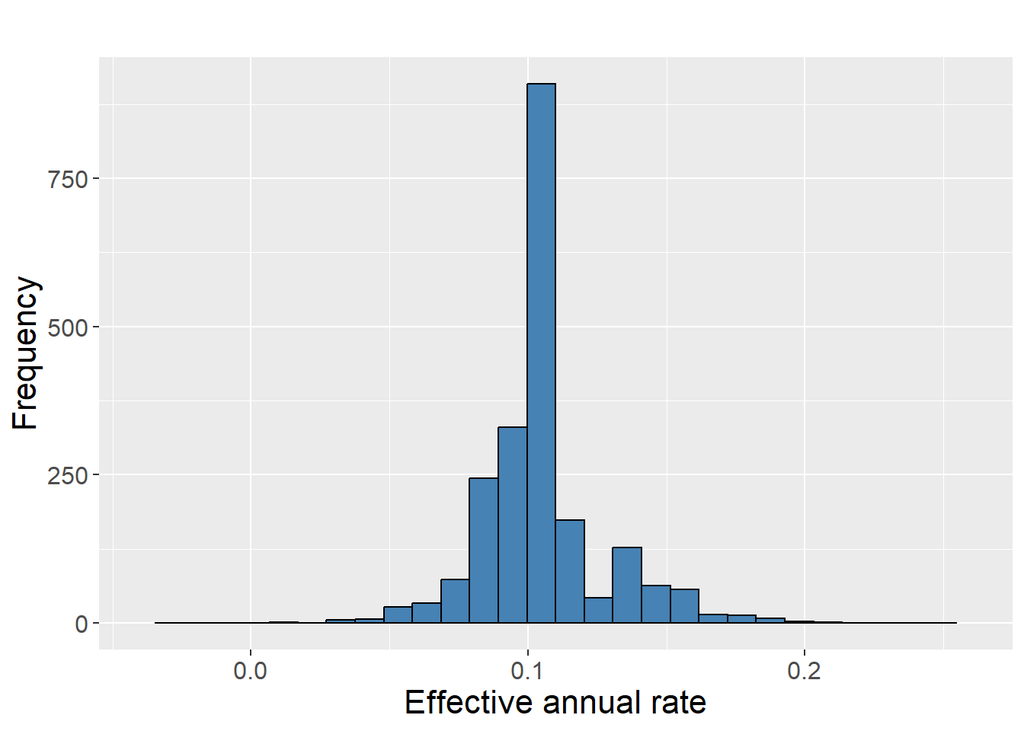

```r
histogramMaker(Chargeoff_Data_Numeric$Effective_Annual_Interest_Rate ,"Effective annual rate","Frequency","")
```

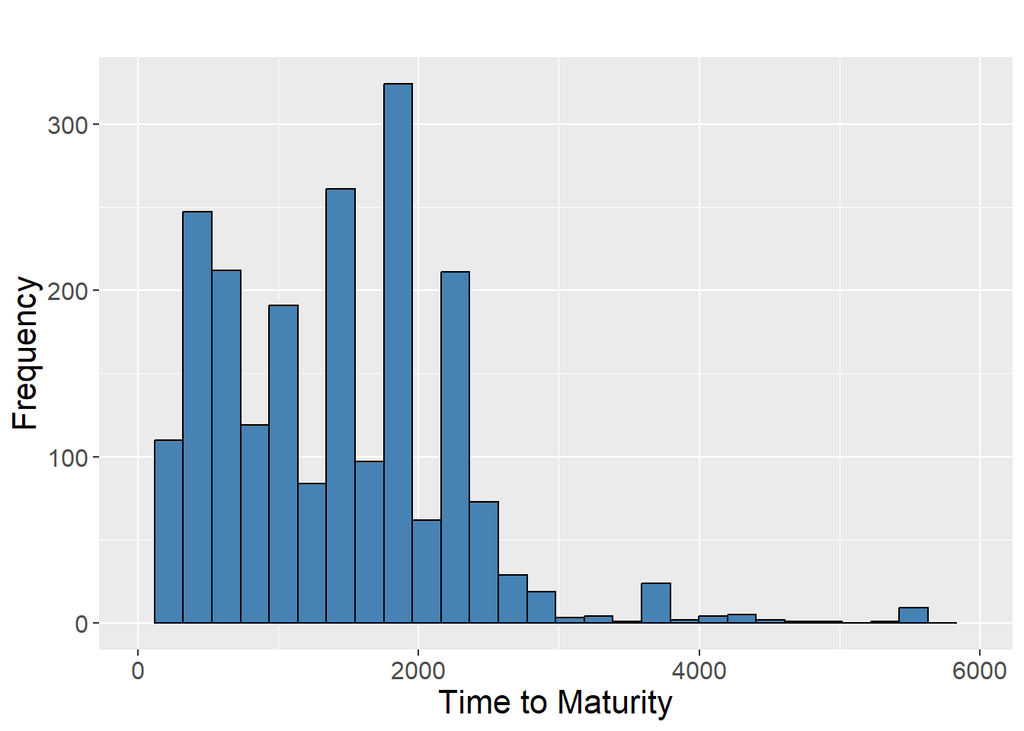

```r
histogramMaker(Chargeoff_Data_Numeric$Time_To_Maturity ,"Time to Maturity","Frequency","")
```

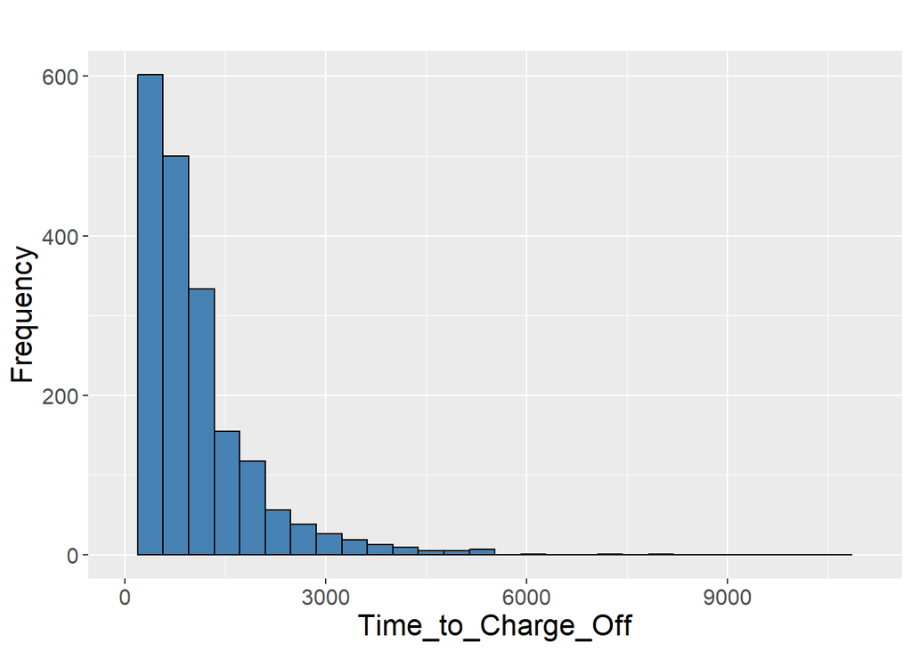

```r
histogramMaker(Chargeoff_Data_Numeric$Time_to_Charge_Off ,"Time_to_Charge_Off","Frequency","")
```

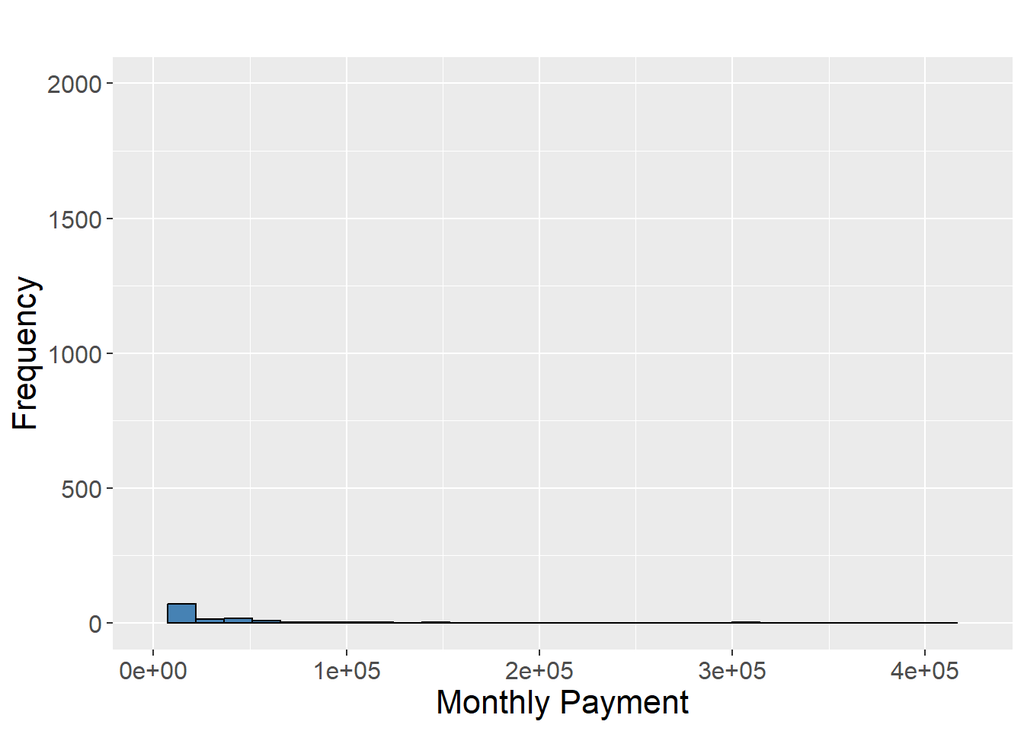

```r
histogramMaker(Chargeoff_Data_Numeric$Monthly_Payment ,"Monthly Payment","Frequency","")
```

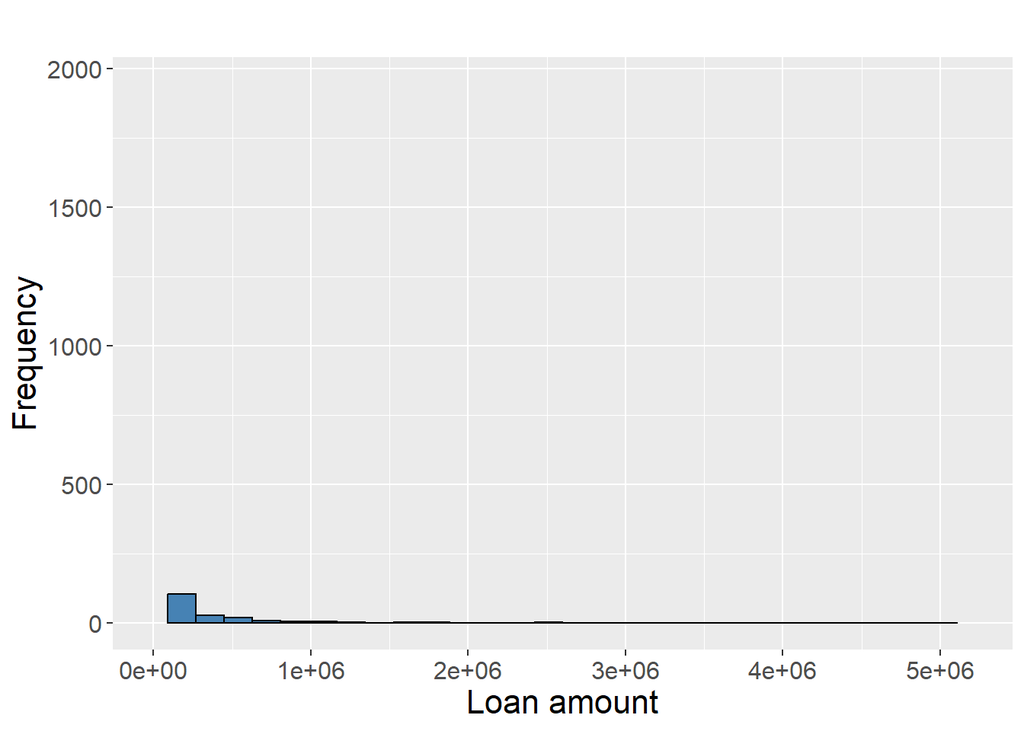

```r
histogramMaker(Chargeoff_Data_Numeric$Original_Loan_Amount ,"Loan amount","Frequency","")
```

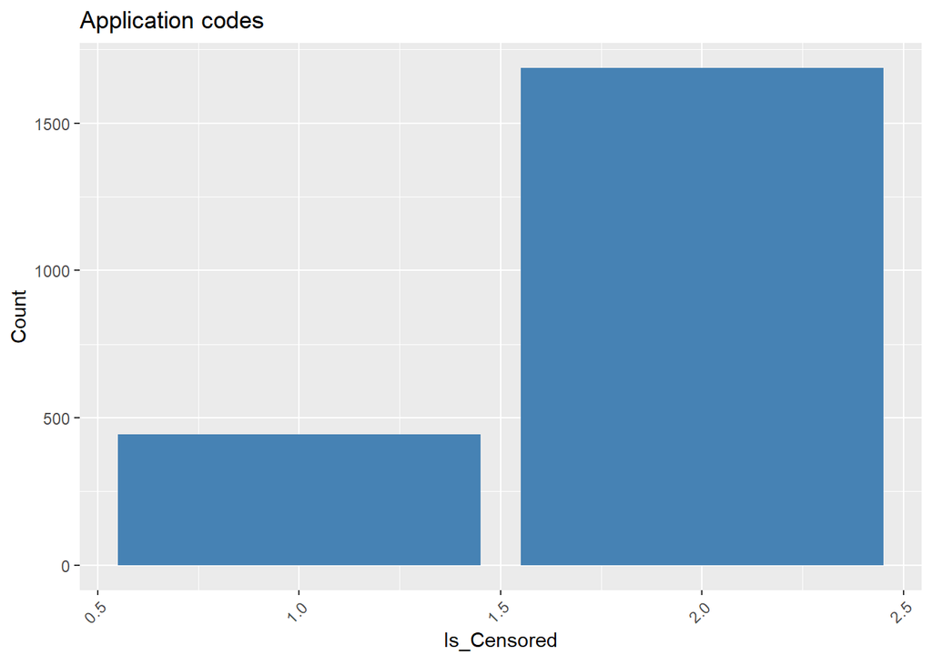

```r
barchartMaker(Chargeoff_Data_Numeric, Is_Censored ,title = "Application codes")
```

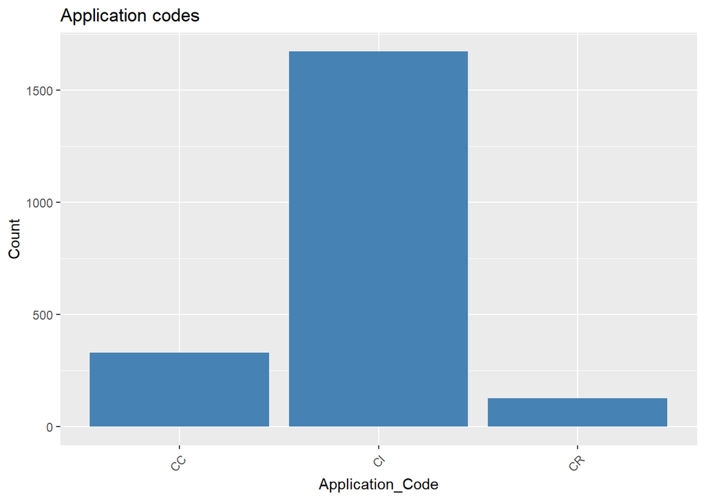

```r
barchartMaker(Chargeoff_Data_Numeric, Application_Code ,title = "Application codes")
```

[figure not shown]

```r
barchartMaker(Chargeoff_Data_Numeric, Product ,title = "Types of loans")
```

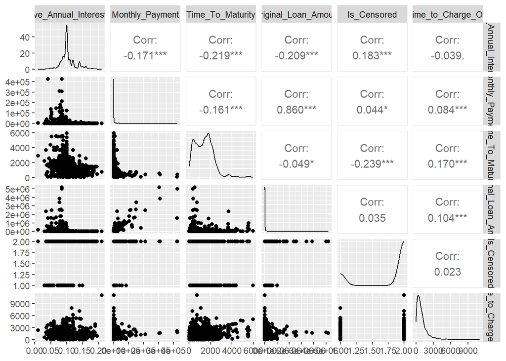

```r
chargeoffNoCategorical = select(Chargeoff_Data_Numeric, Effective_Annual_Interest_Rate, Monthly_Payment, Time_To_Maturity, Original_Loan_Amount, Is_Censored, Time_to_Charge_Off)
ggpairs(chargeoffNoCategorical)
```

Note that there does not seem to be a high correlation between the Is_Censored and Time_to_Charge_Off variables. This will help us meet the non-informative censoring assumption for Cox regression. A log transform is likely needed for monthly payment and original loan amount because there are many outliers for those variables. I found that taking the log of Effective_Annual_Interest_Rate actually helped the model. This surprised me because taking the log of numbers between 0 and 1 actually exaggerates their differences, but doing this seemed to help some model assumptions get met.

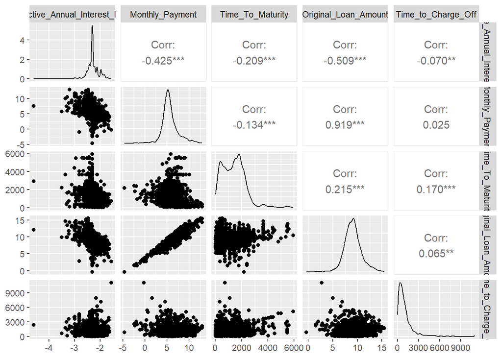

```r
logChargeoff = mutate(Chargeoff_Data_Numeric, Monthly_Payment = log(Monthly_Payment), Original_Loan_Amount = log(Original_Loan_Amount), Effective_Annual_Interest_Rate = log(Effective_Annual_Interest_Rate))
chargeoffNoCategorical = select(logChargeoff, Effective_Annual_Interest_Rate, Monthly_Payment, Time_To_Maturity, Original_Loan_Amount, Time_to_Charge_Off)

ggpairs(chargeoffNoCategorical)
```

There is a strong linear correlation between the log payment and log loan amount. This could cause issues with cox regression, as it is similar to linear regression in that multicollinearity violates the model assumptions. Lets fit a Cox regression model and see if it meets our model assumptions.

```r
coxMod <- coxph(Surv(Time_to_Charge_Off, Is_Censored) ~ Effective_Annual_Interest_Rate + Monthly_Payment + Time_To_Maturity + Original_Loan_Amount+ Application_Code, data = logChargeoff)
coxMod
```

```
Call:
coxph(formula = Surv(Time_to_Charge_Off, Is_Censored) ~ Effective_Annual_Interest_Rate +
    Monthly_Payment + Time_To_Maturity + Original_Loan_Amount +
    Application_Code, data = logChargeoff)

                                     coef  exp(coef)   se(coef)      z        p
Effective_Annual_Interest_Rate  3.518e-01  1.422e+00  1.161e-01  3.030  0.00244
Monthly_Payment                -9.687e-02  9.077e-01  6.857e-02 -1.413  0.15773
Time_To_Maturity               -3.786e-04  9.996e-01  6.233e-05 -6.074 1.25e-09
Original_Loan_Amount            9.777e-02  1.103e+00  7.042e-02  1.388  0.16501
Application_CodeCI              1.316e-01  1.141e+00  7.188e-02  1.831  0.06716
Application_CodeCR             -1.319e-01  8.764e-01  1.131e-01 -1.166  0.24376

Likelihood ratio test=163.5  on 6 df, p=< 2.2e-16
n= 2131, number of events= 1688
```

A few coefficients seem to be significant from the low p values in this model, but we need to check if the model assumptions are met first before we can be confident that these coefficients are reliable.The first and most important assumption to check is the Proportional Hazards assumption.

```r
testPH <- cox.zph(coxMod)
testPH # If p values are high, we can assume the proportional hazards assumption is met.
```

```
                               chisq df       p
Effective_Annual_Interest_Rate  14.3  1 0.00015
Monthly_Payment                 11.3  1 0.00079
Time_To_Maturity               104.6  1 < 2e-16
Original_Loan_Amount            49.0  1 2.5e-12
Application_Code                74.5  2 < 2e-16
GLOBAL                         199.1  6 < 2e-16
```

Our p values are all Bad! This indicates that the model doesn’t meet the proportional hazards assumption primarily because of the Application_Code and Time_To_Maturity variables To counteract this, we could split the data into three models by application code or stratify the model by application code. Stratifying the model by application code makes the baseline hazard different for each application code group while still using all of the data to model the coefficients for the variables. Let’s try that now.

```r
stratCoxMod <- coxph(Surv(Time_to_Charge_Off, Is_Censored) ~ Effective_Annual_Interest_Rate + Monthly_Payment + Time_To_Maturity + Original_Loan_Amount + strata(Application_Code), data = logChargeoff)
stratCoxMod
```

```
Call:
coxph(formula = Surv(Time_to_Charge_Off, Is_Censored) ~ Effective_Annual_Interest_Rate +
    Monthly_Payment + Time_To_Maturity + Original_Loan_Amount +
    strata(Application_Code), data = logChargeoff)

                                     coef  exp(coef)   se(coef)      z        p
Effective_Annual_Interest_Rate  0.3499141  1.4189457  0.1162197  3.011  0.00261
Monthly_Payment                -0.0937585  0.9105027  0.0684711 -1.369  0.17090
Time_To_Maturity               -0.0004059  0.9995941  0.0000625 -6.495 8.33e-11
Original_Loan_Amount            0.0984209  1.1034271  0.0704070  1.398  0.16215

Likelihood ratio test=156  on 4 df, p=< 2.2e-16
n= 2131, number of events= 1688
```

```r
testPH <- cox.zph(stratCoxMod)
testPH
```

```
                                 chisq df      p
Effective_Annual_Interest_Rate   1.417  1 0.2339
Monthly_Payment                  0.388  1 0.5332
Time_To_Maturity               101.058  1 <2e-16
Original_Loan_Amount            13.055  1 0.0003
GLOBAL                         124.731  4 <2e-16
```

The p values are better now that we have stratified the application codes, but the Time_To_Maturity and Original_Loan_Amount variables are causing issues with the proportional hazards assumption. We can also see this graphically by graphing the Schoenfeld residuals against the transformed time. The residuals should be randomly scattered and should form a horizontal line with no real trend as time continues.

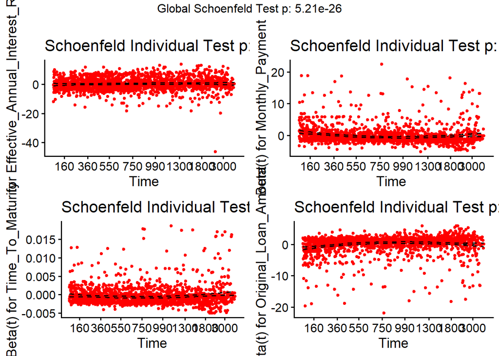

```r
ggcoxzph(testPH)
```

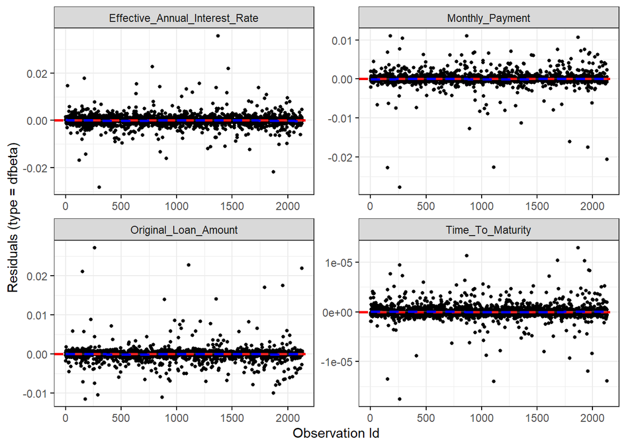

```r
ggcoxdiagnostics(stratCoxMod, type = "dfbeta",
                 linear.predictions = FALSE, ggtheme = theme_bw())
```

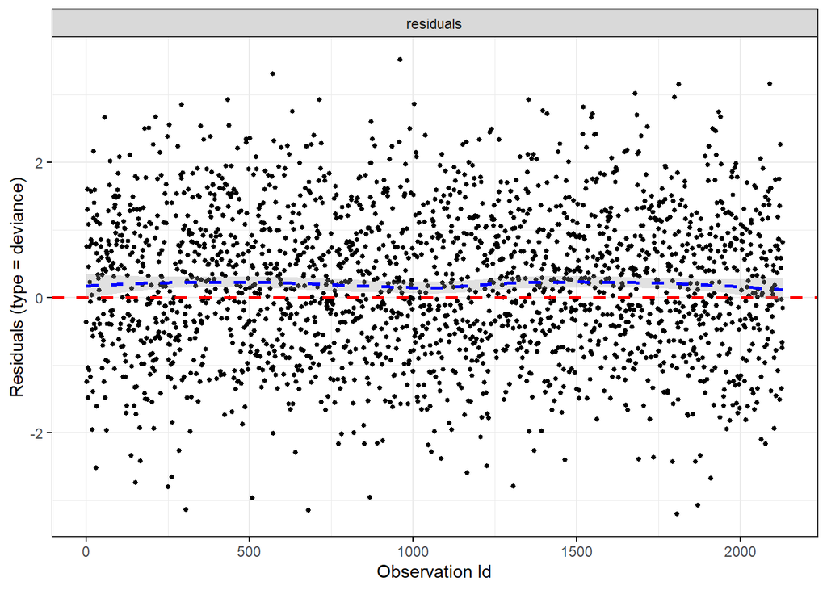

```r
ggcoxdiagnostics(stratCoxMod, type = "deviance",
                 linear.predictions = FALSE, ggtheme = theme_bw())
```

It is fairly symmetric around zero, so we can assume this assumption is reasonably met. Lastly, we need to check if the variables have a linear form. We can check this by plotting the continuous covariates against martingale residuals of the cox proportional hazards model.

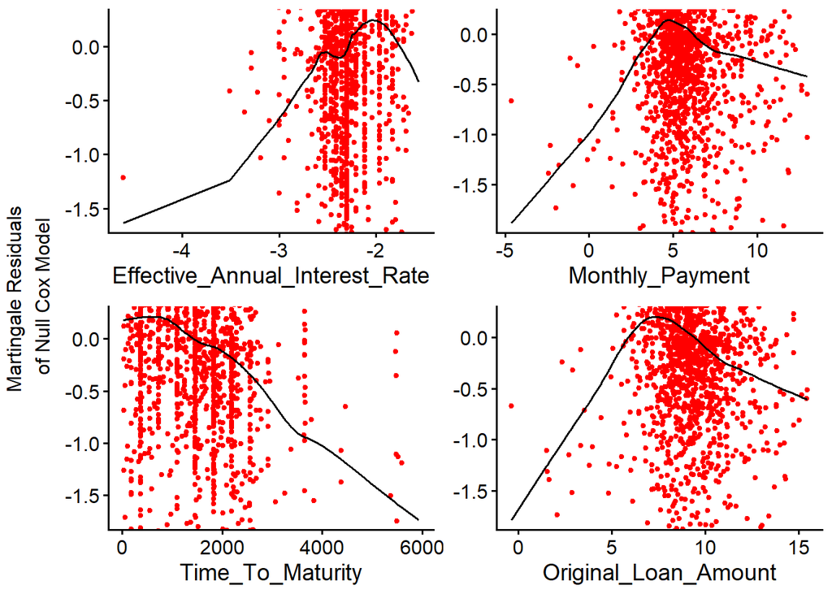

```r
ggcoxfunctional(Surv(Time_to_Charge_Off, Is_Censored) ~ Effective_Annual_Interest_Rate + Monthly_Payment + Time_To_Maturity + Original_Loan_Amount, data = logChargeoff)
```

The variables don’t look great. We will likely need to change our model to better meet these assumptions. One potential issue is multicollinearity, which can be checked with the VIF() function. A VIF above 5 indicates multicollinearity is present.

```r
vif(stratCoxMod)
```

```
                                     GVIF Df GVIF^(1/(2*Df))
Effective_Annual_Interest_Rate   1.270015  1        1.126949
Monthly_Payment                 27.521596  1        5.246103
Time_To_Maturity                 4.090121  1        2.022405
Original_Loan_Amount            26.377343  1        5.135888
strata(Application_Code)       107.107496  0             Inf
```

It appears that some of our VIFs are well above 5. To compensate, we will drop Time_To_Maturity and Original_Loan_Amount, because the monthly payment is more indicative of if the borrower will be able to make payments and uses both dropped variables in its calculation.

```r
VifCoxMod = coxph(Surv(Time_to_Charge_Off, Is_Censored) ~ Effective_Annual_Interest_Rate + Monthly_Payment + strata(Application_Code), data = logChargeoff)
VifCoxMod
```

```
Call:
coxph(formula = Surv(Time_to_Charge_Off, Is_Censored) ~ Effective_Annual_Interest_Rate +
    Monthly_Payment + strata(Application_Code), data = logChargeoff)

                                  coef exp(coef) se(coef)     z        p
Effective_Annual_Interest_Rate 0.67313   1.96036  0.11452 5.878 4.16e-09
Monthly_Payment                0.05381   1.05528  0.01476 3.646 0.000267

Likelihood ratio test=38.12  on 2 df, p=5.289e-09
n= 2131, number of events= 1688
```

```r
vif(VifCoxMod)
```

```
                                   GVIF Df GVIF^(1/(2*Df))
Effective_Annual_Interest_Rate 1.176627  1        1.084724
Monthly_Payment                1.176627  1        1.084724
strata(Application_Code)       1.176627  0             Inf
```

The VIFs look far better now! Let’s check the rest of the assumptions.

```r
testPH = cox.zph(VifCoxMod)
testPH # If p values are high, we can assume the proportional hazards assumption is met.
```

```
                               chisq df    p
Effective_Annual_Interest_Rate 1.819  1 0.18
Monthly_Payment                0.026  1 0.87
GLOBAL                         2.424  2 0.30
```

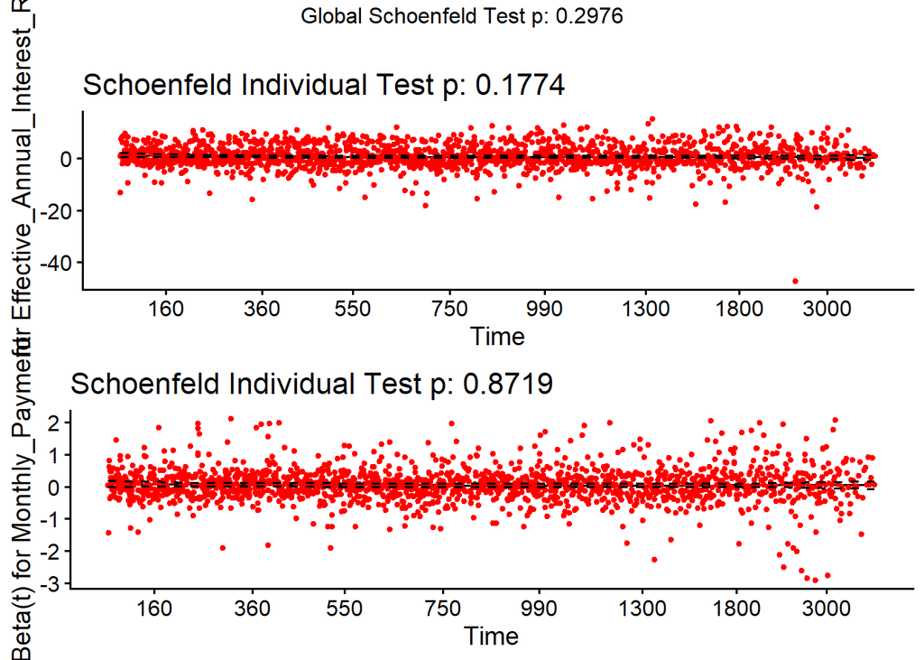

```r
ggcoxzph(testPH)
```

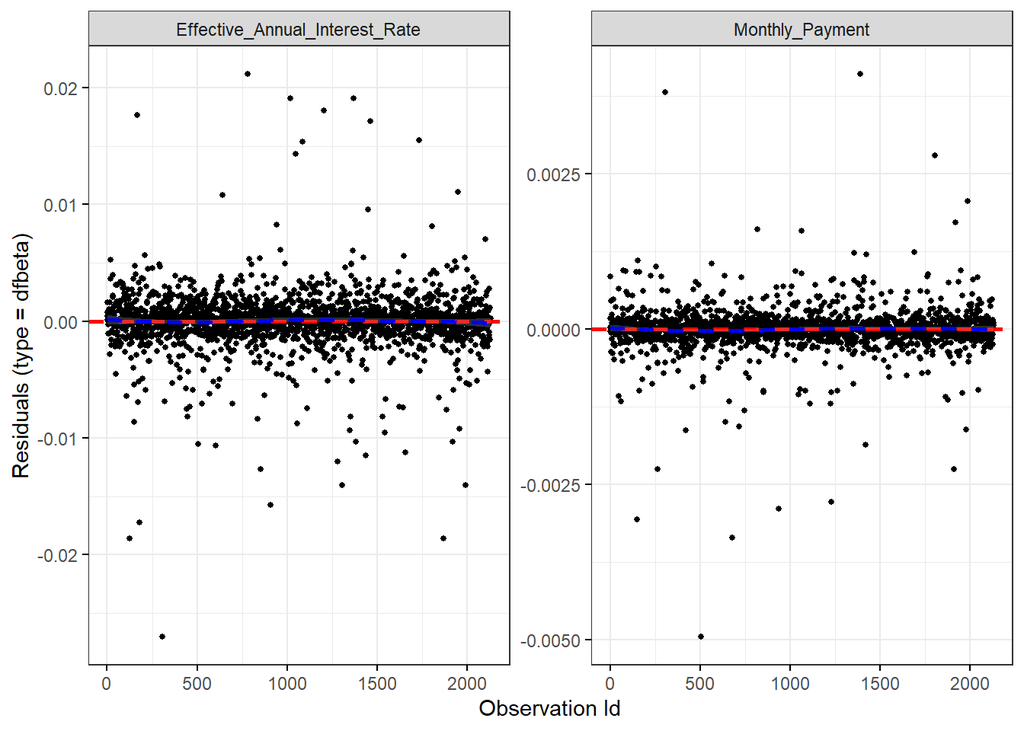

```r
ggcoxdiagnostics(VifCoxMod, type = "dfbeta",
                 linear.predictions = FALSE, ggtheme = theme_bw())
```

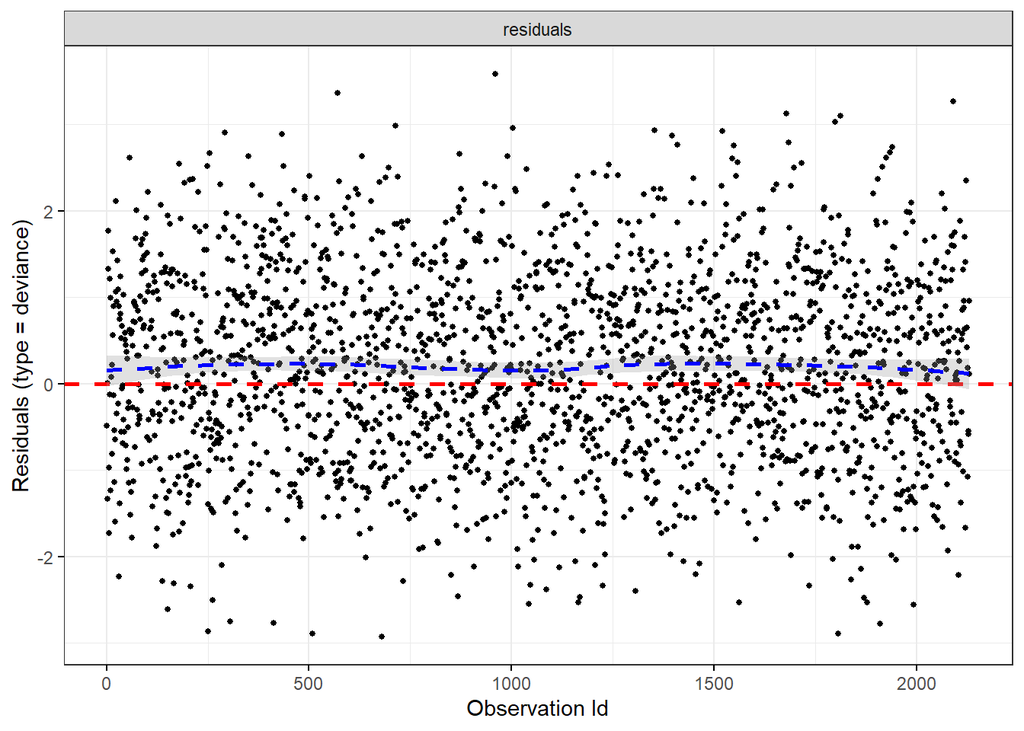

```r
ggcoxdiagnostics(VifCoxMod, type = "deviance",
                 linear.predictions = FALSE, ggtheme = theme_bw())
```

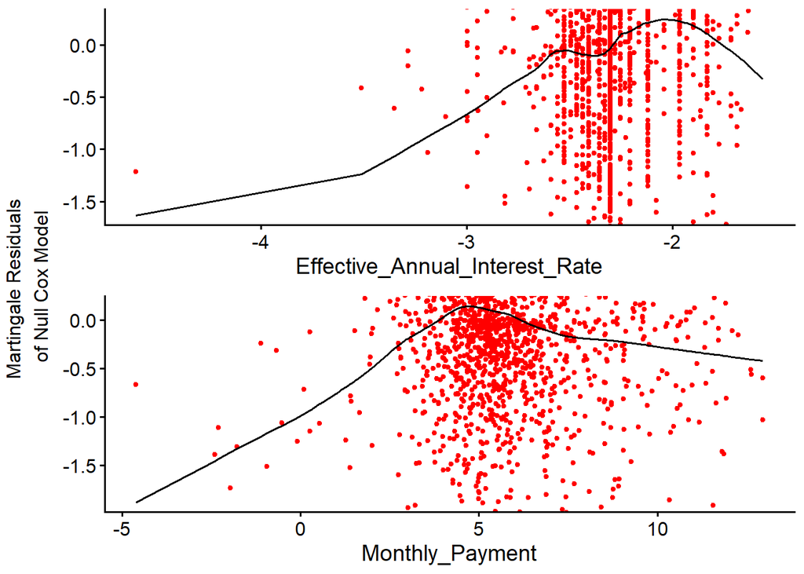

```r
ggcoxfunctional(Surv(Time_to_Charge_Off, Is_Censored) ~ Effective_Annual_Interest_Rate + Monthly_Payment, data = logChargeoff)
```

We can also check the linearity assumption by plotting the martingale residuals vs the payments. the relation should be mostly linear.

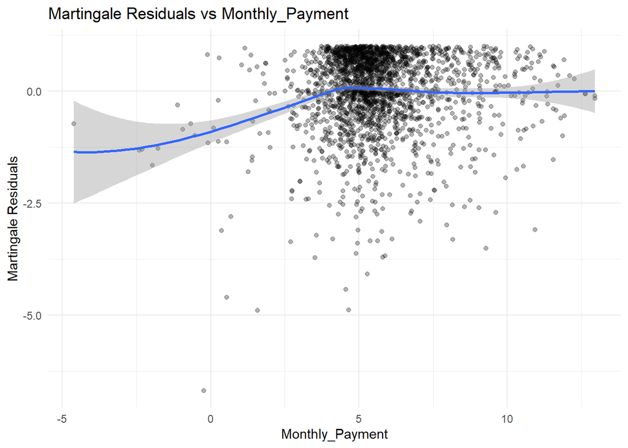

```r
# 1. Fit the model
res.cox = coxph(Surv(Time_to_Charge_Off, Is_Censored) ~ Effective_Annual_Interest_Rate + strata(Application_Code), data = logChargeoff)
# 2. Calculate Martingale residuals
mart_res <- residuals(res.cox, type = "martingale")
martChargeoff = mutate(logChargeoff, martRes = mart_res)
# 3. Plot residuals against the predictor
ggplot(martChargeoff, aes(x = Monthly_Payment, y = mart_res)) +
  geom_point(alpha = 0.3) +
  geom_smooth(method = "loess") + # Adds a trend line
  theme_minimal() +
  labs(title = "Martingale Residuals vs Monthly_Payment",
       y = "Martingale Residuals")
```

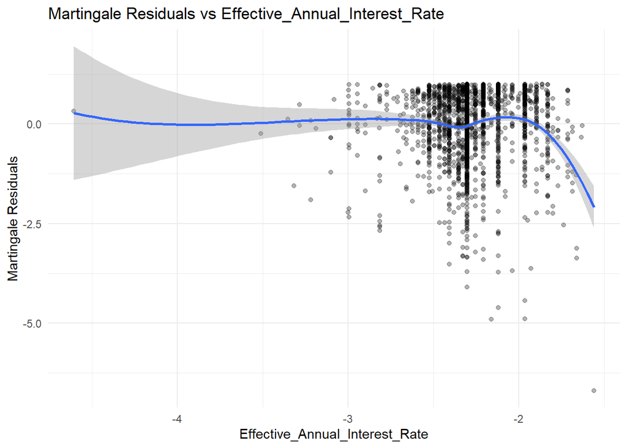

```r
# 1. Fit the model
res.cox <- coxph(Surv(Time_to_Charge_Off, Is_Censored) ~ Effective_Annual_Interest_Rate + strata(Application_Code), data = logChargeoff)
# 2. Calculate Martingale residuals
mart_res <- residuals(res.cox, type = "martingale")
martChargeoff = mutate(logChargeoff, martRes = mart_res)
# 3. Plot residuals against the predictor
ggplot(martChargeoff, aes(x = Effective_Annual_Interest_Rate, y = mart_res)) +
  geom_point(alpha = 0.3) +
  geom_smooth(method = "loess") + # Adds a trend line
  theme_minimal() +
  labs(title = "Martingale Residuals vs Effective_Annual_Interest_Rate",
       y = "Martingale Residuals")
```

Earlier, we stratified our model by Application_ Code. This only works if the coefficients are not very different from each other for each application code, since our stratified model shares the same coefficients across all the categories. Now lets try making separate models for each application code to see if they systematically differ in the way interest rate and loan payment affect them.

```r
CCdata = filter(logChargeoff, Application_Code == "CC")
CRdata = filter(logChargeoff, Application_Code == "CR")
CIdata = filter(logChargeoff, Application_Code == "CI")

CC_CoxMod = coxph(Surv(Time_to_Charge_Off, Is_Censored) ~ Effective_Annual_Interest_Rate + Monthly_Payment, data = CCdata)
CC_CoxMod
```

```
Call:
coxph(formula = Surv(Time_to_Charge_Off, Is_Censored) ~ Effective_Annual_Interest_Rate +
    Monthly_Payment, data = CCdata)

                                  coef exp(coef) se(coef)     z       p
Effective_Annual_Interest_Rate 0.67533   1.96469  0.32173 2.099 0.03581
Monthly_Payment                0.12759   1.13609  0.04158 3.068 0.00215

Likelihood ratio test=11.03  on 2 df, p=0.004017
n= 331, number of events= 271
```

```r
CR_CoxMod = coxph(Surv(Time_to_Charge_Off, Is_Censored) ~ Effective_Annual_Interest_Rate + Monthly_Payment, data = CRdata)
CR_CoxMod
```

```
Call:
coxph(formula = Surv(Time_to_Charge_Off, Is_Censored) ~ Effective_Annual_Interest_Rate +
    Monthly_Payment, data = CRdata)

                                  coef exp(coef) se(coef)     z     p
Effective_Annual_Interest_Rate 0.57815   1.78274  0.45955 1.258 0.208
Monthly_Payment                0.11777   1.12499  0.04795 2.456 0.014

Likelihood ratio test=6.22  on 2 df, p=0.04468
n= 126, number of events= 123
```

```r
CI_CoxMod = coxph(Surv(Time_to_Charge_Off, Is_Censored) ~ Effective_Annual_Interest_Rate + Monthly_Payment, data = CIdata)
CI_CoxMod
```

```
Call:
coxph(formula = Surv(Time_to_Charge_Off, Is_Censored) ~ Effective_Annual_Interest_Rate +
    Monthly_Payment, data = CIdata)

                                  coef exp(coef) se(coef)     z        p
Effective_Annual_Interest_Rate 0.67417   1.96239  0.12605 5.348 8.88e-08
Monthly_Payment                0.03298   1.03353  0.01672 1.972   0.0486

Likelihood ratio test=28.93  on 2 df, p=5.236e-07
n= 1674, number of events= 1294
```

It seems that the coefficients of the models are mostly identical, with one exception being that the effect of Monthly_Payment is a little smaller in Consumer Installment loans. Using stratification makes sense here because individually, we don’t get as much data as if we stratify the model and it would appear that the different application types don’t systematically differ in the way the variables affect them.

Let’s look at the Survival curve for our final stratified model:

```
Ignoring unknown labels:
• colour : "Application Code"
```

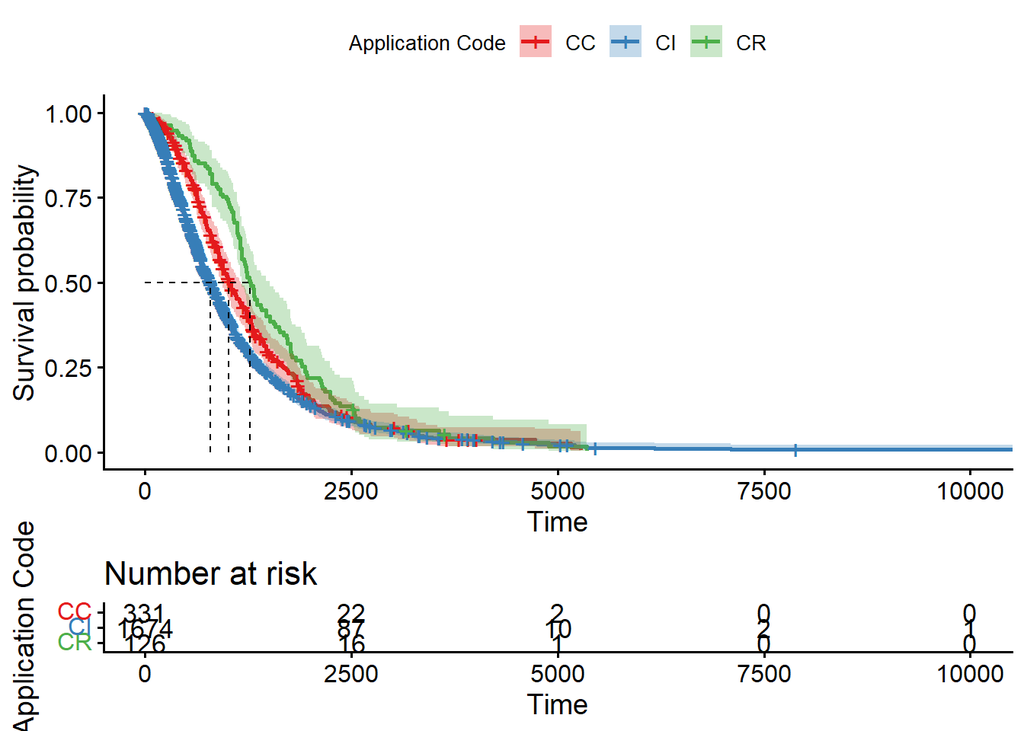

```r
FinalCoxMod = coxph(Surv(Time_to_Charge_Off, Is_Censored) ~ Effective_Annual_Interest_Rate + Monthly_Payment + strata(Application_Code), data = logChargeoff)

fit <- survfit(FinalCoxMod, data = logChargeoff)
ggsurvplot(fit,
           risk.table = TRUE,
           surv.median.line = "hv",
           data = logChargeoff,
           conf.int = TRUE,
           palette = "Set1",
           legend.title = "Application Code", )
```

The survival curve is good, but seems to be influenced by some extreme outliers. There were four loans that had a time to charge off of more than 5500 days (about 15 years), one of which was a $15.90, 2 year loan from 1982 that lasted over 11,000 days before being charged off. I can’t imagine there was any hope this person was tying to pay back their loan 30 years after the loan was issued. So we should use an administrative censor to censor these points at 5500 days after their issuing. This is generally better for our model since we won’t have these extreme outliers, and it will make our graph far easier to observe.

```
Ignoring unknown labels:
• colour : "Application Code"
```

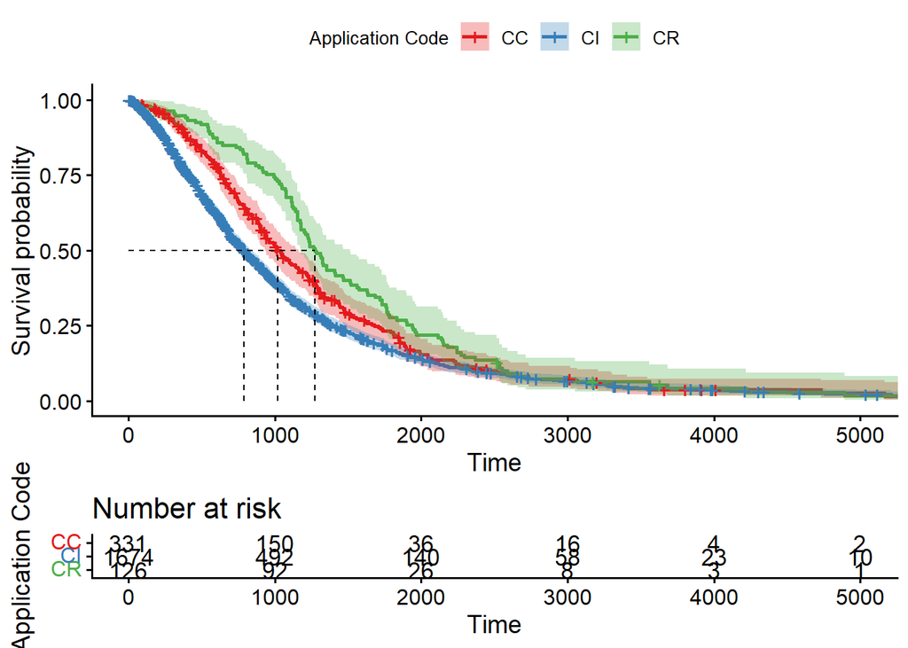

```r
logChargeoffClean = mutate(logChargeoff, Is_Censored = ifelse(Time_to_Charge_Off > 5500, 1, Is_Censored), Time_to_Charge_Off = ifelse(Time_to_Charge_Off > 5500, 5500, Time_to_Charge_Off))

FinalCoxMod = coxph(Surv(Time_to_Charge_Off, Is_Censored) ~ Effective_Annual_Interest_Rate + Monthly_Payment + strata(Application_Code), data = logChargeoffClean)

fit <- survfit(FinalCoxMod, data = logChargeoffClean)
ggsurvplot(fit,
           risk.table = TRUE,
           surv.median.line = "hv",
           data = logChargeoff,
           conf.int = TRUE,
           palette = "Set1",
           legend.title = "Application Code", )
```

One thing I noticed when trying different models was that the term of the loan seemed to have a very significant impact on the model, but made all other variables insignificant. To keep it in the model without causing multicolinearity issues, I am going to try making a model that stratifies the loan by its approximate length:

long: over 5 years medium: 2-5 years short: under 2 years

```
Ignoring unknown labels:
• colour : "Application Code"
```

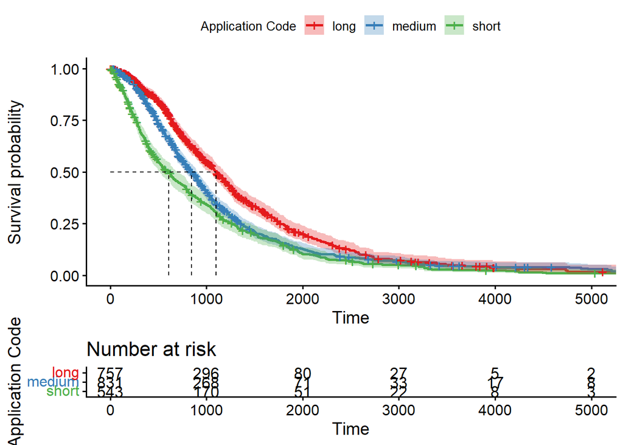

```r
logChargeoffClean2 = mutate(logChargeoffClean, Term = ifelse(Time_To_Maturity > 365*5, "long", "medium"))

logChargeoffClean2 = mutate(logChargeoffClean2, Term = ifelse((Time_To_Maturity <= 365*2), "short", Term))


FinalCoxMod2 = coxph(Surv(Time_to_Charge_Off, Is_Censored) ~ Effective_Annual_Interest_Rate + Monthly_Payment + strata(Term), data = logChargeoffClean2)

fit <- survfit(FinalCoxMod2, data = logChargeoffClean2)
ggsurvplot(fit,
           risk.table = TRUE,
           surv.median.line = "hv",
           data = logChargeoff,
           conf.int = TRUE,
           palette = "Set1",
           legend.title = "Application Code", )
```

As we can see, the term of the loan does have an effect on the survival curve, so we should make a model that also accounts for that. I found that making a model that still stratifies by the Application_Code, but uses the natural log of Time_To_Maturity and the regular Effective_Annual_Interest_Rate was best.

```r
FinalCoxMod2 = coxph(Surv(Time_to_Charge_Off, Is_Censored) ~ exp(Effective_Annual_Interest_Rate) + log(Time_To_Maturity) + strata(Application_Code), data = logChargeoffClean)

testPH = cox.zph(FinalCoxMod2)
testPH # If p values are high, we can assume the proportional hazards assumption is met.
```

```
                                     chisq df      p
exp(Effective_Annual_Interest_Rate)  0.605  1   0.44
log(Time_To_Maturity)               81.895  1 <2e-16
GLOBAL                              81.935  2 <2e-16
```

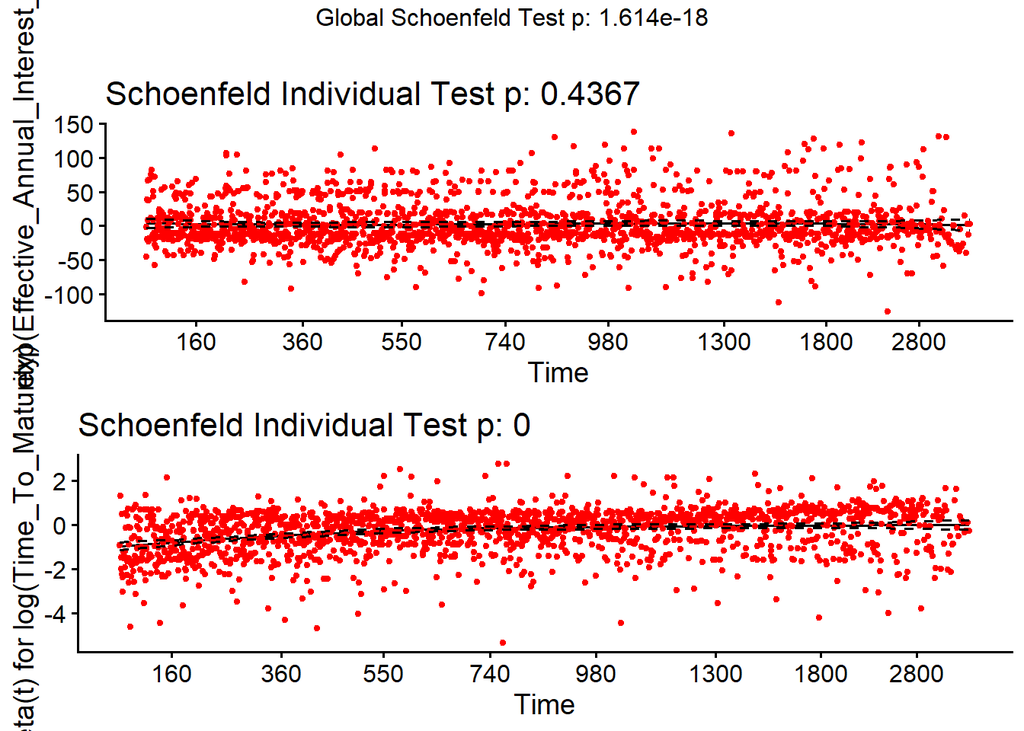

```r
ggcoxzph(testPH)
```

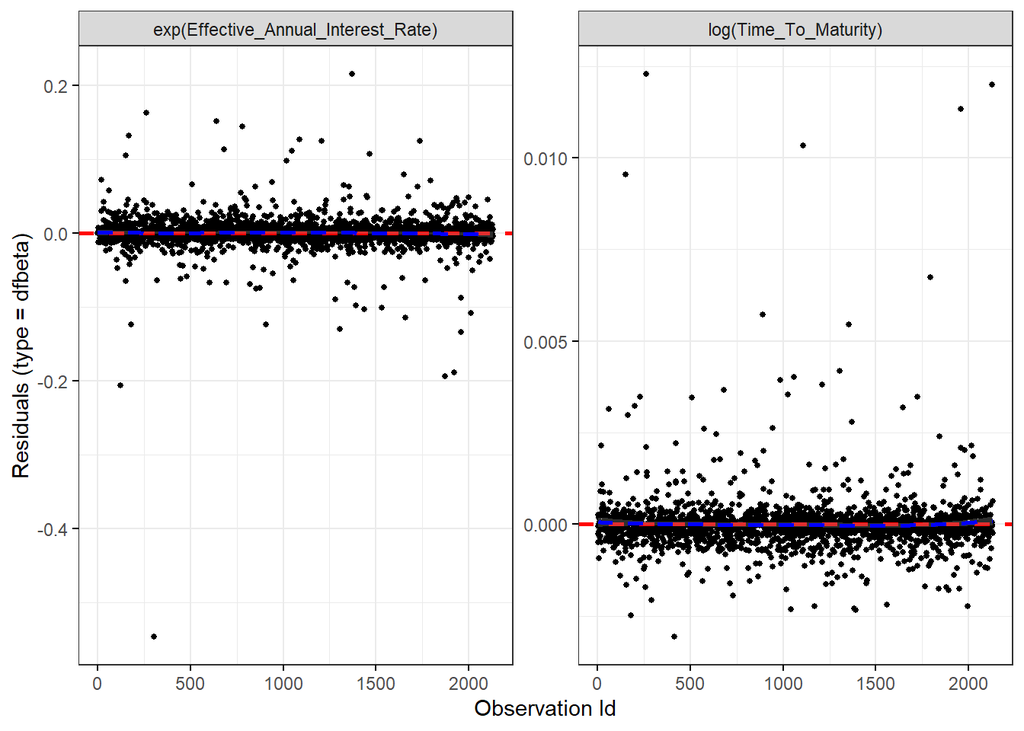

```r
ggcoxdiagnostics(FinalCoxMod2, type = "dfbeta",
                 linear.predictions = FALSE, ggtheme = theme_bw())
```

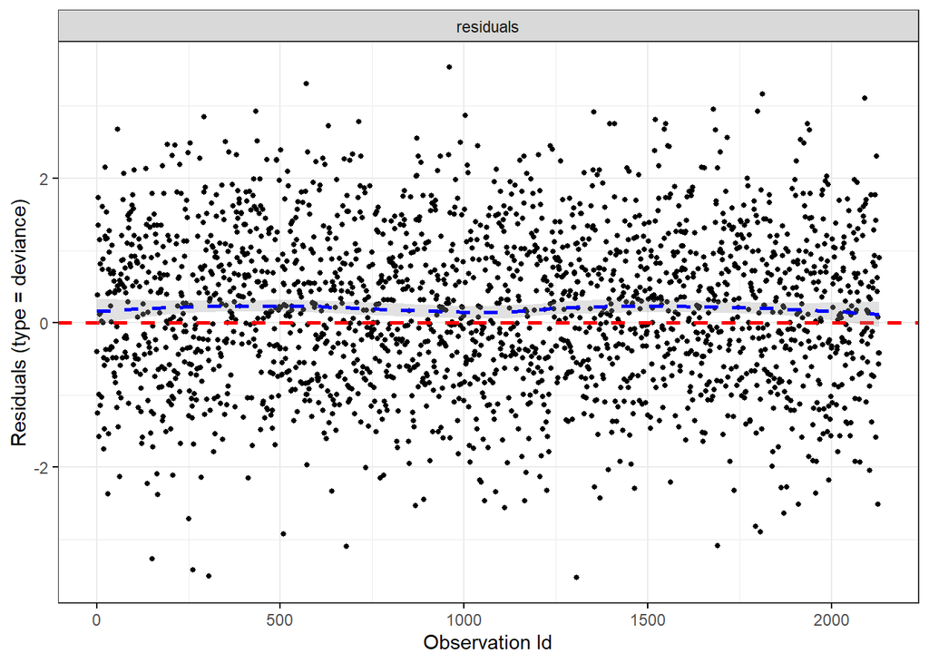

```r
ggcoxdiagnostics(FinalCoxMod2, type = "deviance",
                 linear.predictions = FALSE, ggtheme = theme_bw())
```

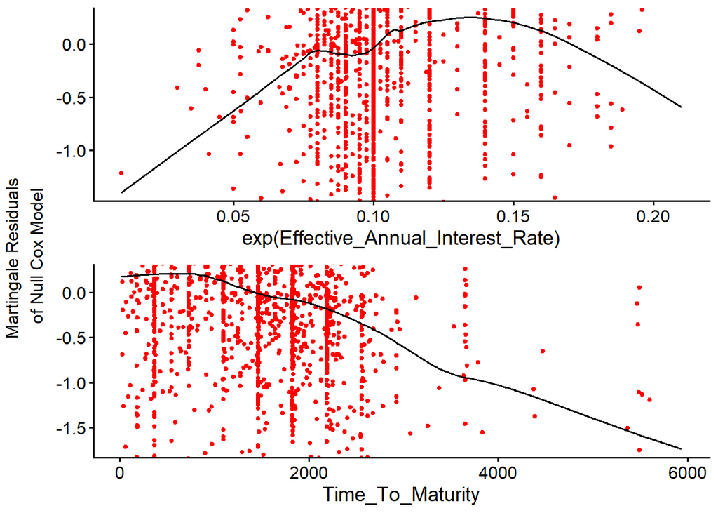

```r
ggcoxfunctional(Surv(Time_to_Charge_Off, Is_Censored) ~ exp(Effective_Annual_Interest_Rate) + Time_To_Maturity, data = logChargeoffClean)
```

Unfortunately it doesn’t seem like we can use this model because of the violation of the proportional hazards assumption. So we will stick with the original model that does not include the term of the loan. In the future, we should investigate further how we can integrate this variable in our model.

#Model Interperetation

Before we interpret our model coefficients, let’s use the model to predict how some hypothetical loans will perform. We will consider two loans. One loan will have a payment of $1000 a month and an effective annual interest rate of 25%, and the other will have a payment of $100 a month and an effective annual interest rate of 2.5%.

```r
badLoan = data.frame( Monthly_Payment = log(1000), Effective_Annual_Interest_Rate = log(0.25), Application_Code = "CI")

goodLoan = data.frame( Monthly_Payment = log(100), Effective_Annual_Interest_Rate = log(0.025), Application_Code = "CI")
```

Note that we take the log of both Monthly_Payment and Effective_Annual_Interest_Rate. This is because our model was trained on the logged variables instead of the regular ones, so we must apply the same transformation to these variables too. Now let’s see how these loans compare to the average loan in their category.

```r
predict(FinalCoxMod, goodLoan, type = "risk")
```

```
        1
0.3662471
```

This specific loan profile is 0.3662471 times less likely to charge off at any given moment than the average Installment or Traditional Consumer Loan. This indicates it is significantly less risky than the average loan in the Installment or Traditional Consumer Loans category.

```r
predict(FinalCoxMod, badLoan, type = "risk")
```

```
       1
1.956174
```

This specific loan profile is 1.956174 times more likely to charge off at any given moment than the average Installment or Traditional Consumer Loan.

```r
specificFit = survfit(FinalCoxMod, newdata = goodLoan)
summary(specificFit, times = c(365))
```

```
Call: survfit(formula = FinalCoxMod, newdata = goodLoan)

                1
        time       n.risk      n.event     survival      std.err lower 95% CI
     365.000     1197.000      352.000        0.913        0.015        0.884
upper 95% CI
       0.943
```

This summary gives a 95% confidence interval for the loan’s true probability of survival up to 365 days from issuance, and some other general information. We can interpret this as:

For an installment or traditional consumer loan with a payment of $100 a month and an effective annual interest rate of 2.5% that will eventually charge off, we are 95% confident that the true probability of the loan not charging off for one year is between 88.4% and 94.3%.

```r
specificFit = survfit(FinalCoxMod, newdata = badLoan)
summary(specificFit, times = c(365))
```

```
Call: survfit(formula = FinalCoxMod, newdata = badLoan)

                1
        time       n.risk      n.event     survival      std.err lower 95% CI
     365.000     1197.000      352.000        0.615        0.036        0.549
upper 95% CI
       0.690
```

For an installment or traditional consumer loan with a payment of $1000 a month and an effective annual interest rate of 25% that will eventually charge off, we are 95% confident that the true probability of the loan not charging off for one year is between 54.9% and 69.0%.

Using the model for predicting a loan’s risk is likely the best use case for our model. However we can still glean some valuable information from our model coefficients. Our final model that best met Cox regression’s assumptions can be written as:

$$\hat{\lambda_g(t)} = \lambda_{0_g}(t) * e^{0.67445 * ln(EAR) + 0.05318 * ln(Monthly\, Payment)}$$

Where EAR is the effective annual interest rate, Monthly Payment is the monthly payment that would be made on the loan if it were paid through even payments throughout the life of the loan, $\hat{\lambda_g(t)}$ is the hazard at time t for group g, and $\lambda_{0_g}(T)$ is the Baseline hazard for group g, the type of the loan which is either Commercial Loans, Installment or Traditional Consumer Loans, or Real Estate.

Our coefficients can be interpreted using the model summary output we found earlier. Recall that our coefficients were 0.67445 for EAR and 0.05318 for monthly payment. The exponentiated coefficients were 1.96295 and 1.05462 respectively. We can interpret the exponentiated coefficients as:

a 2.718 times increase in the EAR, holding all other variables constant, is associated with a 96.295% increase in the hazard of chargeoff.

a 2.718 times increase in the monthly payment, holding all other variables constant, is associated with a 5.462% increase in the hazard of chargeoff.

These aren’t the most parsimonious interpretations though, so we can also express these as a percentage using the coefficients instead.

A 10% increase in the monthly payment is associated with a 0.5081% increase in the hazard of charge-off.

Unfortunately because we have stratified the model by application code, there is not a clear way to interpret each code’s effect on the model. While this does loose us some information, the added benefit of having a better predictive model that meets the model assumptions is more important.

# Conclusions and Recommendations

We can conclude from our findings that a higher interest rate plays a major role in the risk of charge off for loans that will eventually charge off. While the supposed monthly payment is less impactful, a very large payment will also increase the hazard of charge off. There appears to be a significant separation between application codes, so the application code should be considered when assessing risk as well.

While our findings here were from a dataset that only included loans that would charge off eventually, the same process can easily be applied to a mix of loans that will charge off and ones that won’t. If this cox regression model were to be applied to a mixed dataset, it could be used to better assess the risk of all loans before they are issued. This could be very helpful for lending decision making, as it could be used to determine the probable loss from a loan, and determine if lending is profitable given the probability of a charge off at a certain point in time. Tracking additional variables like the applicant’s credit score, debt to income ratio, age, gender, and income at the time of application could also improve model performance. We would recommend that State Bank of Southern Utah further investigate creating a database with information on all previous loans and their status of charge off, so creating such a model would be possible.